# Temporal trends

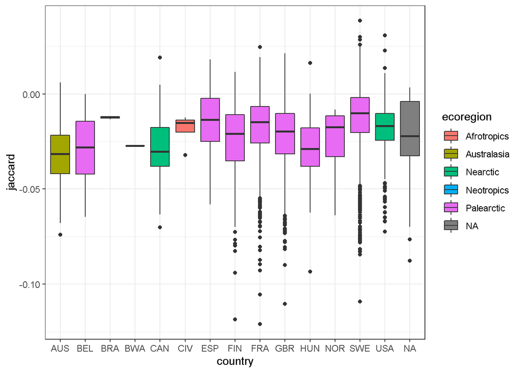

```r
rigal_trends_df_loc %>%
  ggplot(aes(x = country, y = jaccard, fill = ecoregion)) +
  geom_boxplot()
```

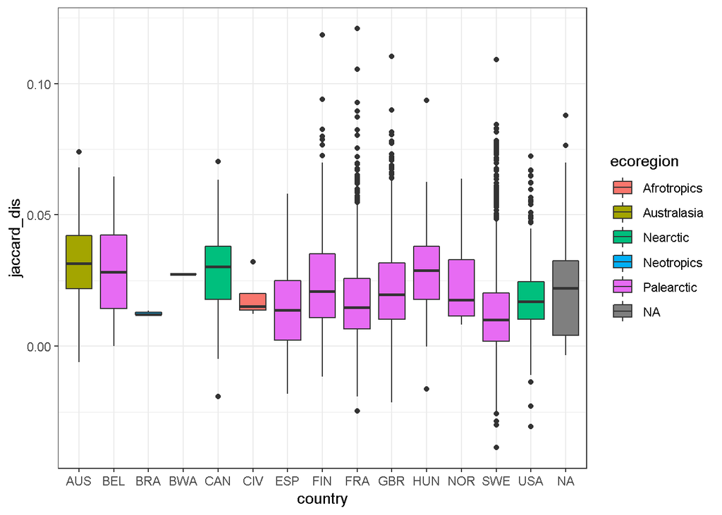

```r
rigal_trends_df_loc %>%
  ggplot(aes(x = country, y = jaccard_dis, fill = ecoregion)) +
  geom_boxplot()
```

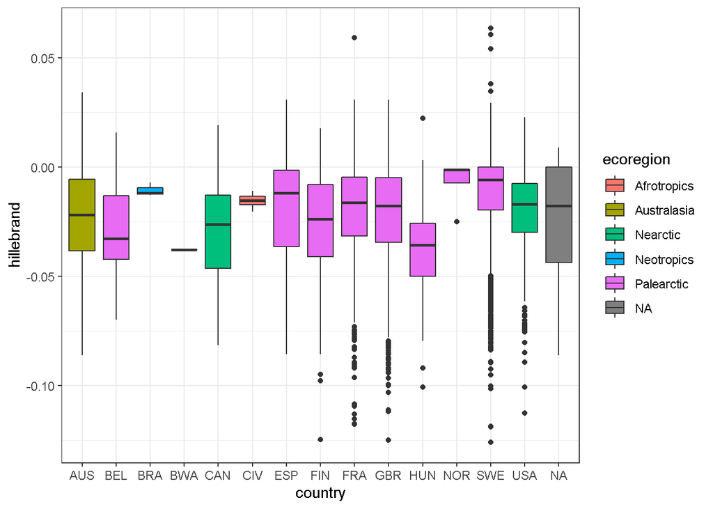

```r
rigal_trends_df_loc %>%
    ggplot(aes(x = country, y = hillebrand, fill = ecoregion)) +
    geom_boxplot()
```

```r
rigal_trends_df_loc <- filtered_dataset$location %>%
  left_join(rigal_trends_df, by = "siteid") %>%
  st_as_sf(coords = c("longitude", "latitude"),
  crs = 4326)
```

```r
library(colorspace)
div_pal <- colorspace::sequential_hcl(11, "plasma")
world <- ne_countries(returnclass = "sf")

bb <- st_bbox(rigal_trends_df_loc)
```

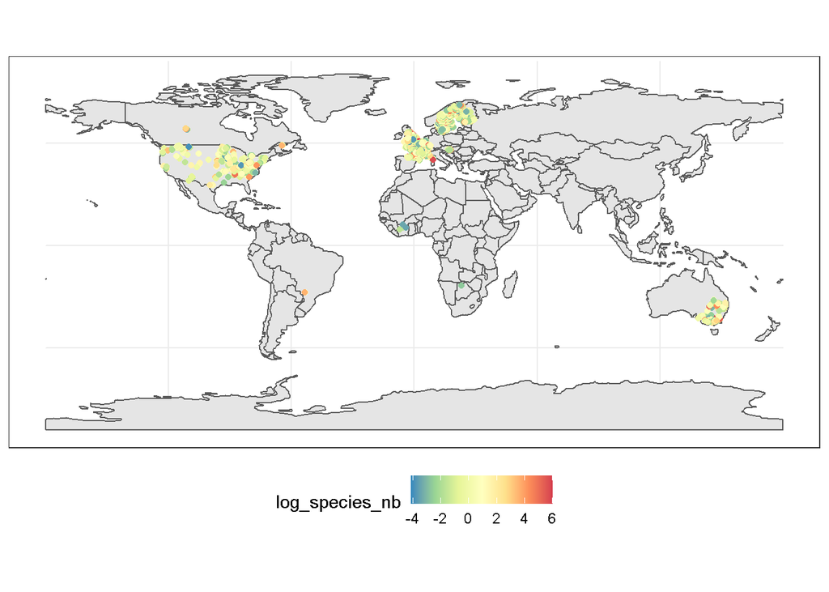

```r
map_world_trends(df = rigal_trends_df_loc, y = "log_species_nb")
```

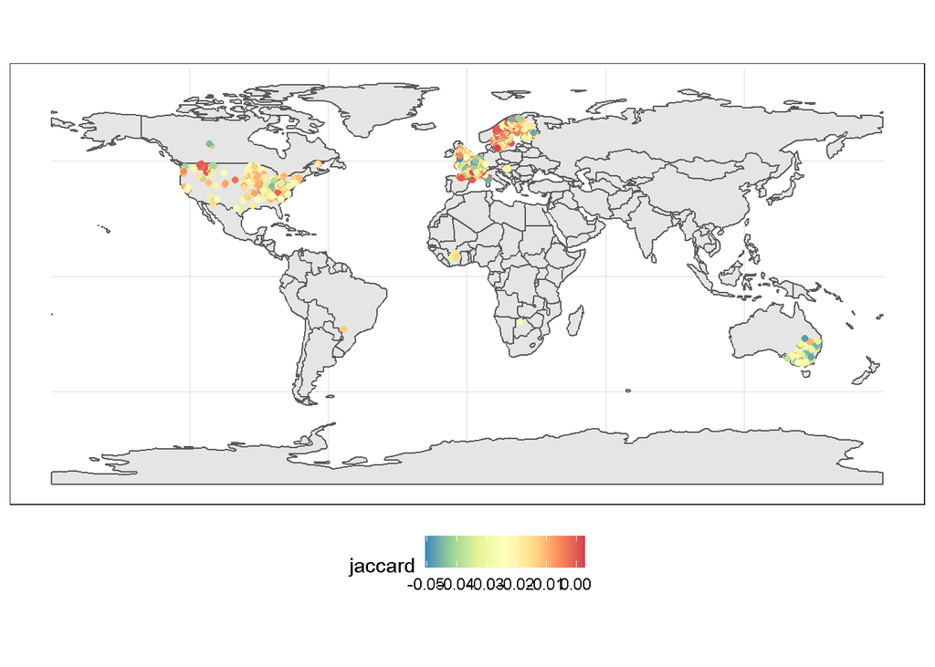

```r
map_world_trends(df = rigal_trends_df_loc, y = "jaccard")
```

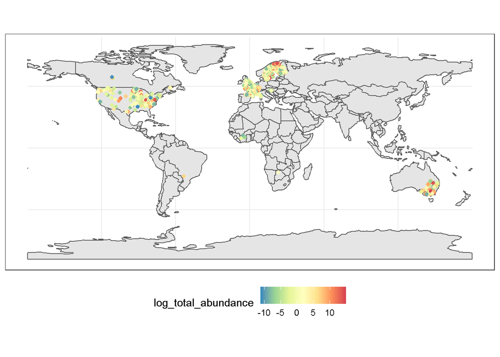

```r
map_world_trends(df = rigal_trends_df_loc, y = "log_total_abundance")
```

```r
rigal_trends_df %>%
  summarise(across(where(is.numeric), median, na.rm = T)) %>%
  unlist()
```

```
#>     total_abundance log_total_abundance          species_nb      log_species_nb
#>        9.553162e-02        5.582744e-01        3.893853e-03        1.305570e-01
#>       chao_richness        chao_shannon        chao_simpson       chao_evenness
#>        2.787916e-03        3.308454e-03        2.601314e-03        0.000000e+00
#>             jaccard                horn                chao          hillebrand
#>       -1.527040e-02       -1.041153e-02       -3.884971e-17       -1.343464e-02
#>               total          appearance       disappearance            evenness
#>        1.195970e-02        5.364436e-03        3.065584e-03        2.796551e-05
#>             shannon             simpson         jaccard_dis          nestedness
#>        8.848320e-04        2.939331e-04        1.527040e-02        5.342415e-03
#>            turnover
#>        2.203876e-03
```

```r
median(exp(rigal_trends_df$log_total_abundance) - 1)  * 100
```

```
#> [1] 74.76598
```

```r
sd(exp(rigal_trends_df$log_total_abundance) - 1) * 100
```

```
#> [1] 1.494478e+35
```

```r
median(exp(na.omit(rigal_trends_df$log_species_nb))  - 1) * 100
```

```
#> [1] 13.94629
```

```r
sd(exp(na.omit(rigal_trends_df$log_species_nb)) - 1) * 100
```

```
#> [1] 1.551331e+19
```

# 8 Sensibility analysis of temporal trends

```r
slope_avg3y <- map_dfr(rigal_trends_avg3y[
  ! names(rigal_trends_avg3y) %in% c("jaccard_dis", "nestedness", "turnover")], ~.x %>%
  select(siteid, linear_slope),
.id = "response"
)
```

- Number of sites that are in the different datasets:

```r
u_site <- map(list(classic = slope, avg_3y = slope_avg3y), ~unique(.x$siteid))
sum(u_site[[1]] %in% u_site[[2]])
```

```
#> [1] 5516
```

```r
sum(u_site[[2]] %in% u_site[[1]])
```

```
#> [1] 5516
```

```r
comparison_baseline <- rbind(
  slope %>%
    mutate(type = "classic") %>%
    filter(siteid %in% u_site[["avg_3y"]]),
  slope_avg3y %>%
    mutate(type = "avg_3y")
  ) %>%
pivot_wider(names_from = type, values_from = linear_slope)
```

- It is not too bad, but we can see some differences:
  - slope negatively biaised for `log_species_nb` in 3 years baseline
  - Bunch of trends in appearance/disappearance trends disappears with  
    3 years baseline
  - But note that in three years baseline, there are three points less data

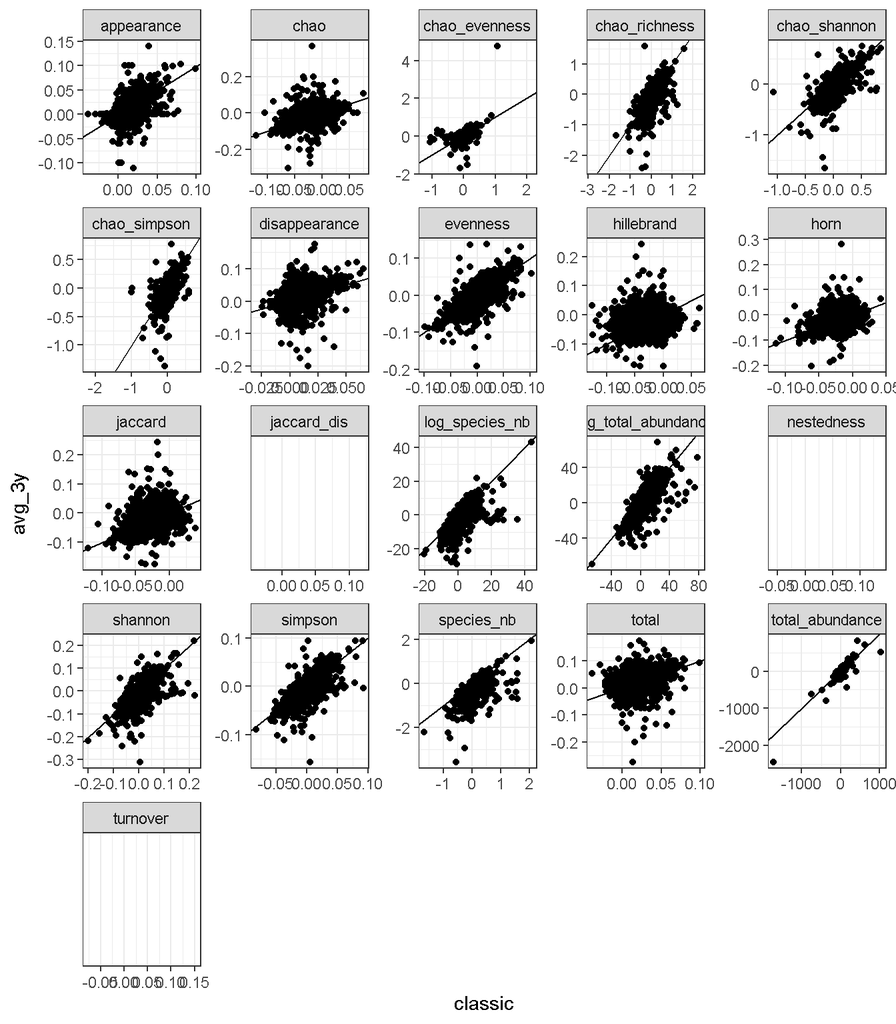

```r
comparison_baseline %>%
  ggplot(aes(x = classic, y = avg_3y)) +
  geom_point() +
  geom_abline(intercept = 0, slope = 1) +
  facet_wrap(~response, scale = "free")
```

# 9 Environment

```r
col_to_keep <- get_river_atlas_significant_var()
names(col_to_keep) <- NULL

riv <- riveratlas_site %>%
  clean_names() %>%
  select(all_of(c("siteid", col_to_keep))) %>%
  st_drop_geometry()
```

```r
slp_riv <- slope_df %>%
  select(siteid, log_species_nb, evenness, turnover, nestedness, hillebrand,
    appearance, disappearance, jaccard) %>%
left_join(riv, by = "siteid") %>%
left_join(select(filtered_dataset$location, siteid, ecoregion, main_bas, latitude, longitude), by = "siteid")

length(unique(slp_riv$main_bas))
```

```
#> [1] 309
```

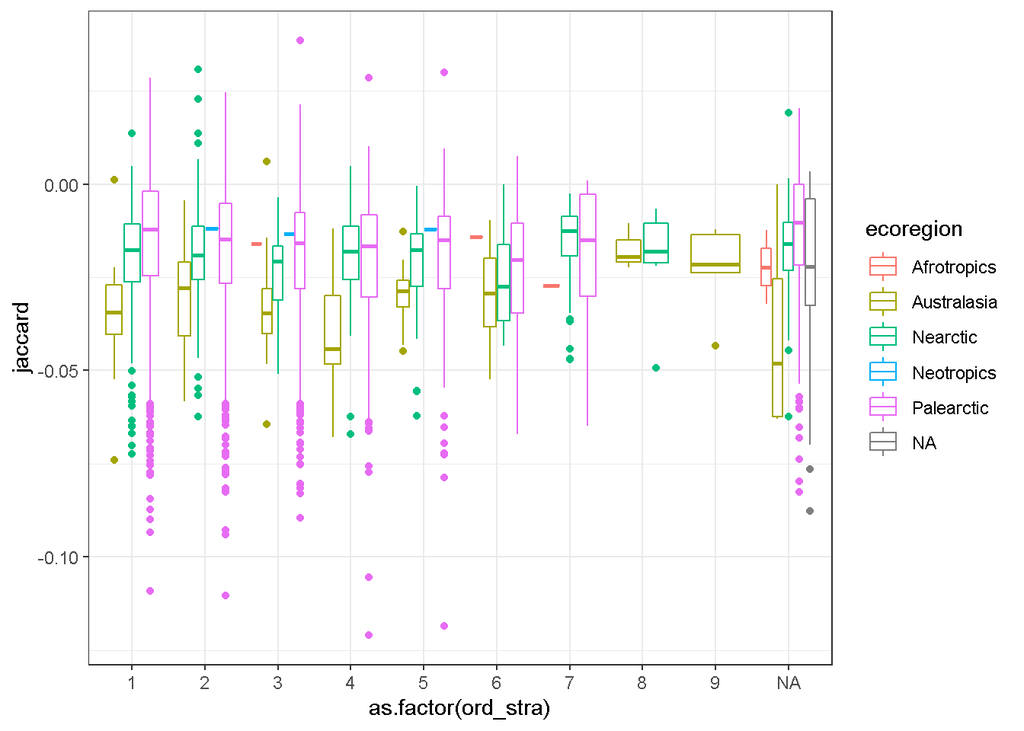

```r
slp_riv %>%
  ggplot(aes(y = jaccard, x = as.factor(ord_stra), color = ecoregion)) +
  geom_boxplot()
```

```
#> Warning: Removed 600 rows containing non-finite values (stat_smooth).
#> Warning: Removed 600 rows containing missing values (geom_point).
```

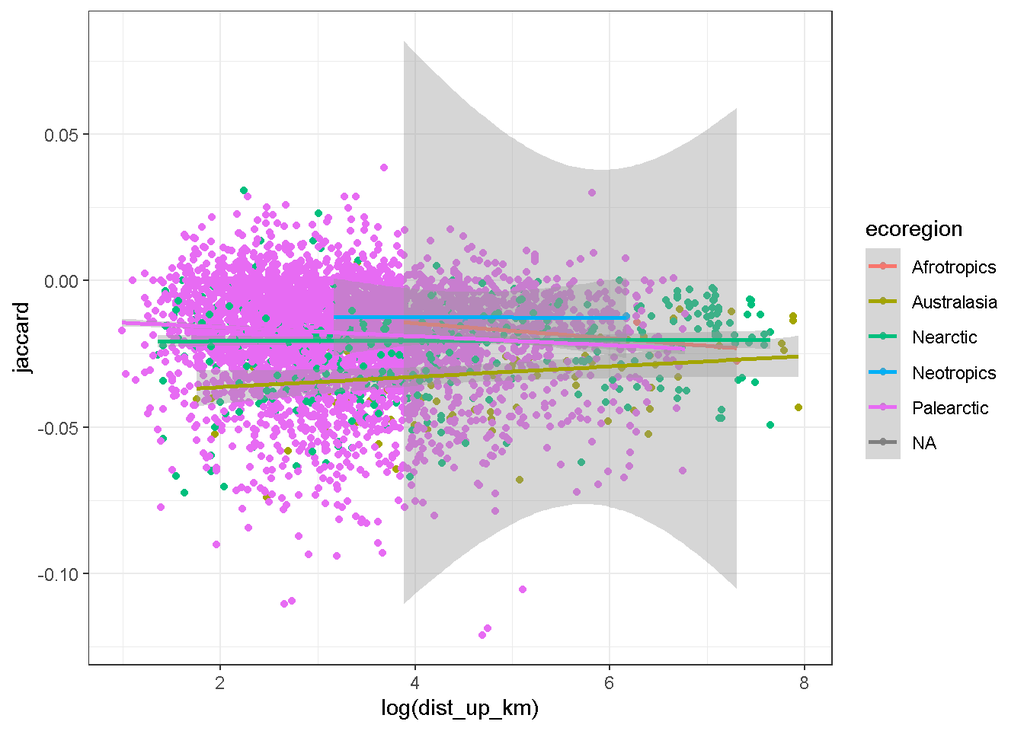

```r
slp_riv %>%
  ggplot(aes(y = jaccard, x = log(dist_up_km), color = ecoregion)) +
  geom_point() +
  geom_smooth(method = "lm")
```

```
#> Warning: Removed 600 rows containing non-finite values (stat_smooth).
#> Removed 600 rows containing missing values (geom_point).
```

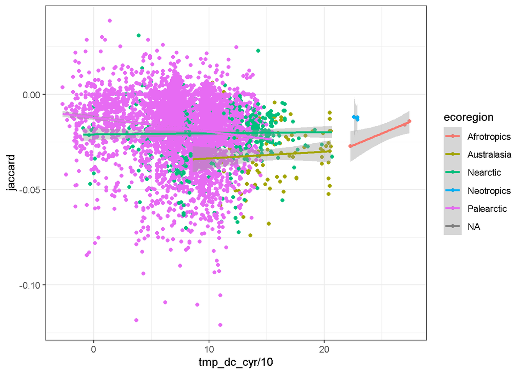

```r
# slp_riv %>%
#   ggplot(aes(y = jaccard, x = as.factor(ord_flow), color = ecoregion)) +
#   geom_boxplot()

slp_riv %>%
  ggplot(aes(y = jaccard, x = tmp_dc_cyr /10, color = ecoregion)) +
  geom_point() +
  geom_smooth(method = "lm")
```

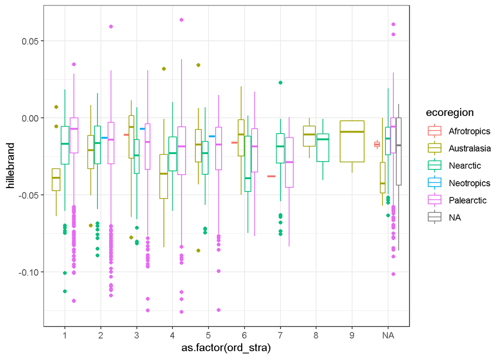

```r
slp_riv %>%
  ggplot(aes(y = hillebrand, x = as.factor(ord_stra), color = ecoregion)) +
  geom_boxplot()
```

```
#> Warning: Removed 600 rows containing non-finite values (stat_smooth).
#> Warning: Removed 600 rows containing missing values (geom_point).
```

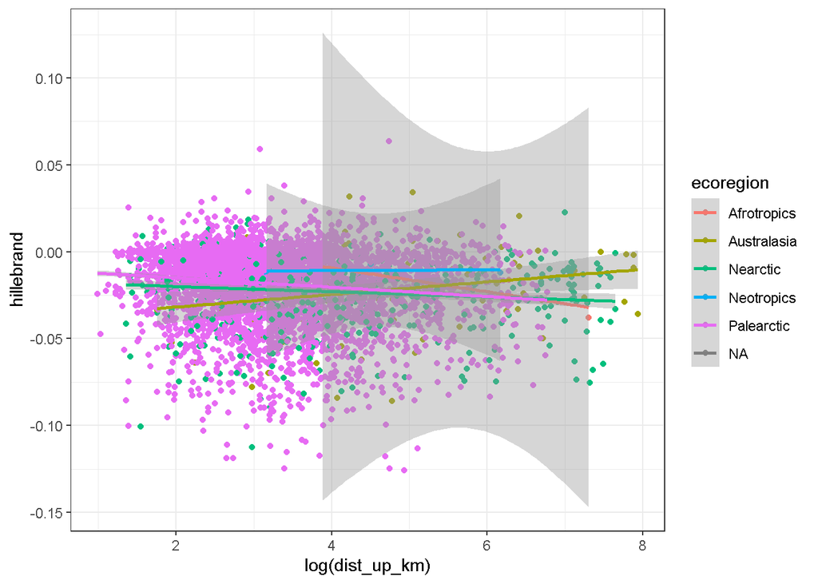

```r
slp_riv %>%
  ggplot(aes(y = hillebrand, x = log(dist_up_km), color = ecoregion)) +
  geom_point() +
  geom_smooth(method = "lm")
```

```
#> Warning: Removed 600 rows containing non-finite values (stat_smooth).
#> Removed 600 rows containing missing values (geom_point).
```

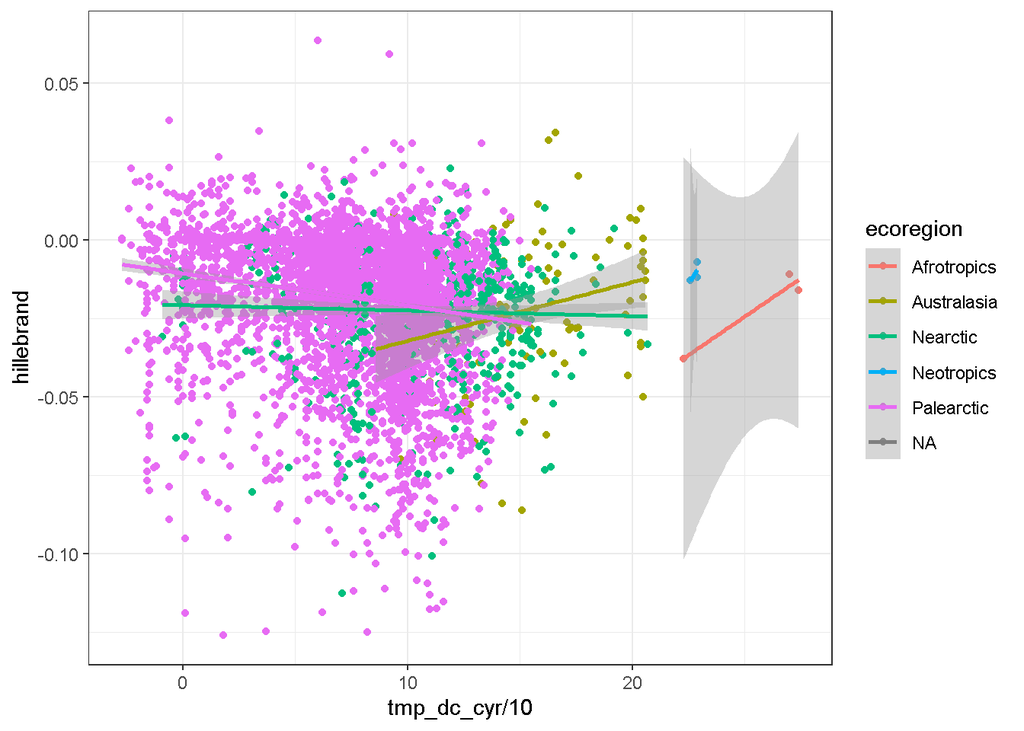

```r
slp_riv %>%
  ggplot(aes(y = hillebrand, x = tmp_dc_cyr / 10, color = ecoregion)) +
  geom_point() +
  geom_smooth(method = "lm")
```

```
#> Warning: Removed 600 rows containing non-finite values (stat_smooth).
#> Warning: Removed 600 rows containing missing values (geom_point).
```

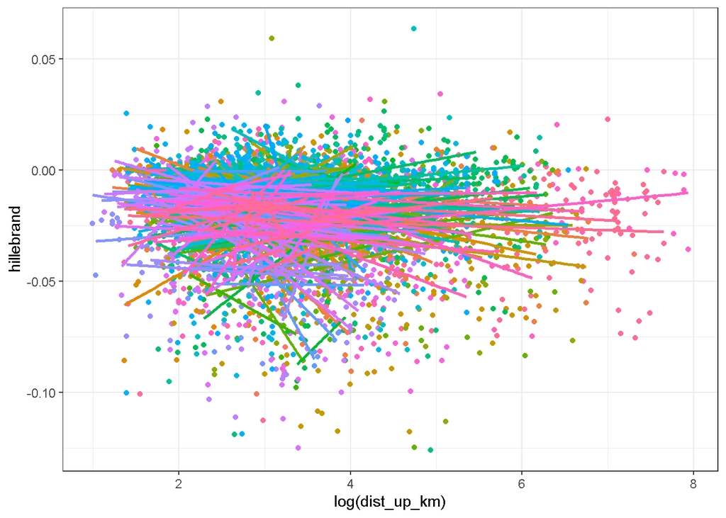

```r
slp_riv %>%
  ggplot(aes(y = hillebrand, x = log(dist_up_km), color = as.factor(main_bas))) +
  geom_point() +
  geom_smooth(method = "lm", se = FALSE) +
  theme(legend.position = "none")
```

```
#> Warning: Removed 600 rows containing non-finite values (stat_smooth).
#> Removed 600 rows containing missing values (geom_point).
```

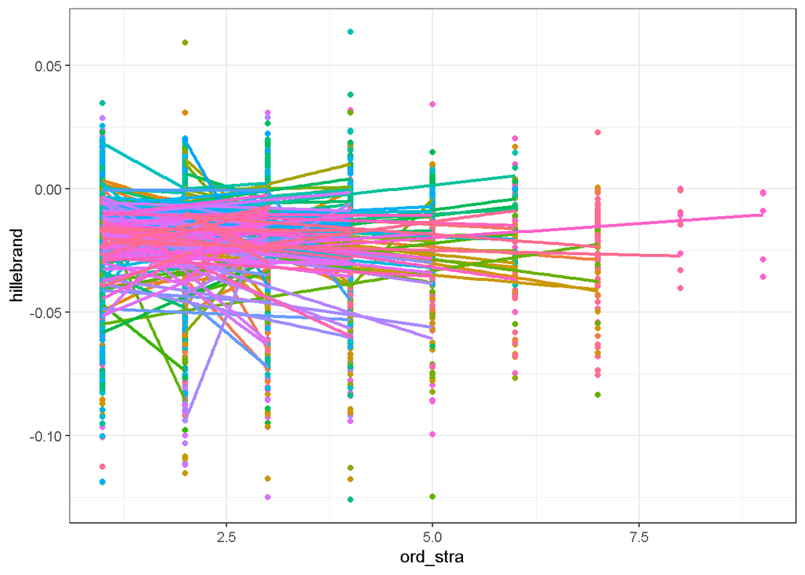

```r
slp_riv %>%
  ggplot(aes(y = hillebrand, x = ord_stra, color = as.factor(main_bas))) +
  geom_point() +
  geom_smooth(method = "lm", se = FALSE) +
  theme(legend.position = "none")
```

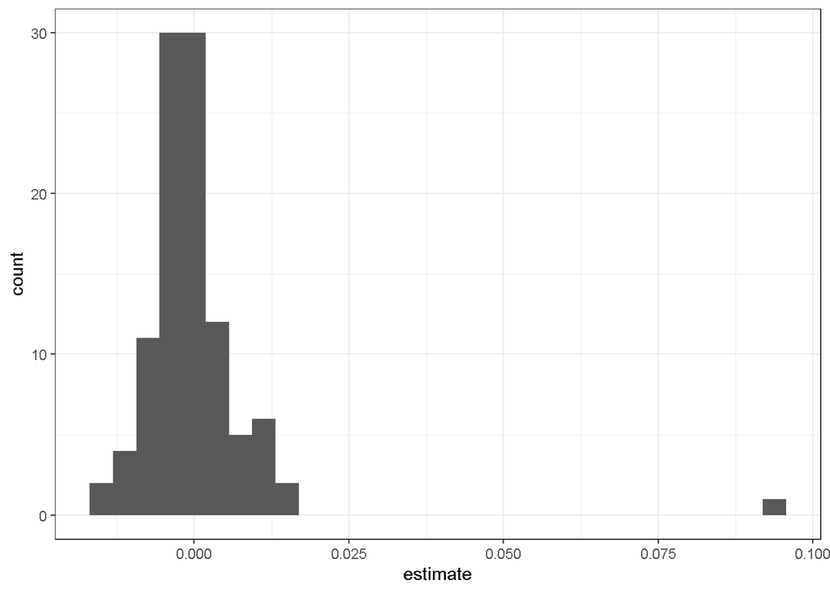

```r
ti <- slp_riv %>%
 nest_by(main_bas) %>%
 filter(nrow(data) > 10 & sum(!is.na(data$dist_up_km)) > 10)

tu <- ti %>%
  mutate(
    m = list(lm(jaccard ~ log(dist_up_km), data = data)),
    coef = list(broom::tidy(m))
  ) %>%
  unnest(coef) %>%
  filter(term == "log(dist_up_km)")

tu %>%
  ggplot(aes(x = estimate)) +
  geom_histogram()
```

```r
summary(lm(jaccard ~ log(dist_up_km), slp_riv))
```

```
#>
#> Call:
#> lm(formula = jaccard ~ log(dist_up_km), data = slp_riv)
#>
#> Residuals:
#>       Min        1Q    Median        3Q       Max
#> -0.100741 -0.008875  0.002875  0.012125  0.057293
#>
#> Coefficients:
#>                   Estimate Std. Error t value Pr(>|t|)
#> (Intercept)     -0.0139322  0.0007663 -18.181  < 2e-16 ***
#> log(dist_up_km) -0.0013307  0.0002148  -6.196 6.25e-10 ***
#> ---
#> Signif. codes:  0 '***' 0.001 '**' 0.01 '*' 0.05 '.' 0.1 ' ' 1
#>
#> Residual standard error: 0.0171 on 4914 degrees of freedom
#>   (600 observations deleted due to missingness)
#> Multiple R-squared:  0.007753,   Adjusted R-squared:  0.007551
#> F-statistic: 38.39 on 1 and 4914 DF,  p-value: 6.25e-10
```

## 9.1 Human footprint

```r
colnames(riveratlas_site)[
  str_detect(colnames(riveratlas_site),
    "hft_ix_")]
```

```
#> [1] "hft_ix_c93" "hft_ix_u93" "hft_ix_c09" "hft_ix_u09"
```

```r
hftc <- riveratlas_site[,
        colnames(riveratlas_site) %in%
          c("siteid", "hft_ix_c93", "hft_ix_c09")
        ] %>%
        st_drop_geometry() %>%
        mutate(
          cat_hft_ix_c09 = cut(hft_ix_c09, 6),
          cat_hft_ix_c93 = cut(hft_ix_c93, 6),
          hft_ix_c9309_percent =
            (hft_ix_c09 - hft_ix_c93) / hft_ix_c93 * 100,
          hft_ix_c9309_ratio = hft_ix_c09 / hft_ix_c93,
          hft_ix_c9309_log_ratio = log(hft_ix_c9309_ratio),
          hft_ix_c9309_diff = hft_ix_c09 - hft_ix_c93,
          log_hft_ix_c9309_percent = log(hft_ix_c9309_percent),
          cat_hftc9309 = cut(hft_ix_c9309_percent, 6),
          cat_hft_ix_c9309_log_ratio = cut(hft_ix_c9309_log_ratio, 6)
        )
skimr::skim(hftc)
```

Table 9.1: Data summary

| Name | hftc |
| --- | --- |
| Number of rows | 4916 |
| Number of columns | 12 |
| _______________________ |  |
| Column type frequency: |  |
| character | 1 |
| factor | 4 |
| numeric | 7 |
| ________________________ |  |
| Group variables | None |

**Variable type: character**

| skim_variable | n_missing | complete_rate | min | max | empty | n_unique | whitespace |
| --- | --- | --- | --- | --- | --- | --- | --- |
| siteid | 0 | 1 | 2 | 6 | 0 | 4916 | 0 |

**Variable type: factor**

| skim_variable | n_missing | complete_rate | ordered | n_unique | top_counts |
| --- | --- | --- | --- | --- | --- |
| cat_hft_ix_c09 | 0 | 1 | FALSE | 6 | (77: 1391, (1.: 1247, (15: 871, (22: 629 |
| cat_hft_ix_c93 | 0 | 1 | FALSE | 6 | (77: 1254, (1.: 1077, (15: 958, (22: 694 |
| cat_hftc9309 | 0 | 1 | FALSE | 3 | (-7: 4913, (22: 2, (1.: 1, (51: 0 |
| cat_hft_ix_c9309_log_ratio | 0 | 1 | FALSE | 6 | (-0: 2866, (-0: 1970, (-1: 59, (0.: 18 |

**Variable type: numeric**

| skim_variable | n_missing | complete_rate | mean | sd | p0 | p25 | p50 | p75 | p100 | hist |
| --- | --- | --- | --- | --- | --- | --- | --- | --- | --- | --- |
| hft_ix_c93 | 0 | 1.00 | 182.44 | 112.87 | 2.00 | 85.00 | 165.50 | 268.25 | 456.00 | ▇▇▆▅▂ |
| hft_ix_c09 | 0 | 1.00 | 169.08 | 111.71 | 2.00 | 77.00 | 142.00 | 250.00 | 456.00 | ▇▇▅▃▂ |
| hft_ix_c9309_percent | 0 | 1.00 | -6.46 | 33.05 | -76.92 | -18.03 | -4.10 | 0.00 | 1709.09 | ▇▁▁▁▁ |
| hft_ix_c9309_ratio | 0 | 1.00 | 0.94 | 0.33 | 0.23 | 0.82 | 0.96 | 1.00 | 18.09 | ▇▁▁▁▁ |
| hft_ix_c9309_log_ratio | 0 | 1.00 | -0.09 | 0.22 | -1.47 | -0.20 | -0.04 | 0.00 | 2.90 | ▁▇▁▁▁ |
| hft_ix_c9309_diff | 0 | 1.00 | -13.37 | 28.21 | -122.00 | -29.00 | -6.00 | 0.00 | 188.00 | ▁▇▂▁▁ |
| log_hft_ix_c9309_percent | 3089 | 0.37 | -Inf | NaN | -Inf | -Inf | 0.58 | 2.13 | 7.44 | ▃▇▆▁▁ |

```
#> Warning: Removed 3690 rows containing non-finite values (stat_bin).
```

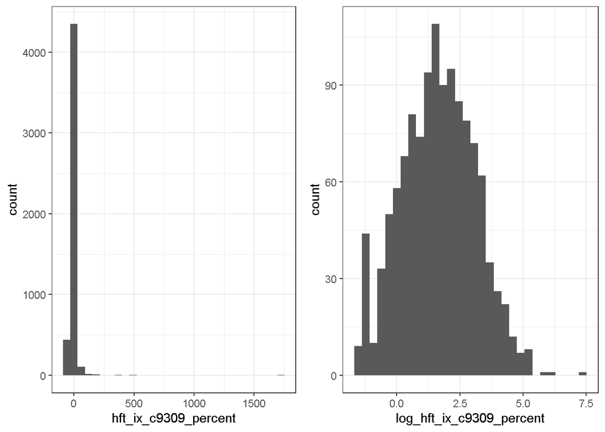

```r
p_hft_diff <- map(c("hft_ix_c9309_percent", "log_hft_ix_c9309_percent"),
  ~hftc %>%
  ggplot(aes_string(x = .x)) +
  geom_histogram()
)
plot_grid(plotlist = p_hft_diff)
```

```r
hftc_biodiv <- analysis_dataset %>%
  left_join(hftc, by = "siteid")
```

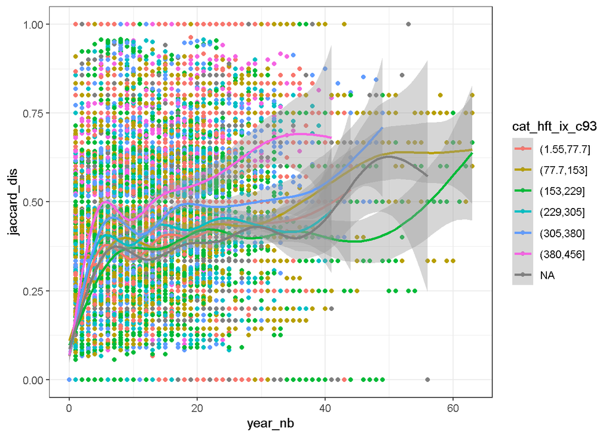

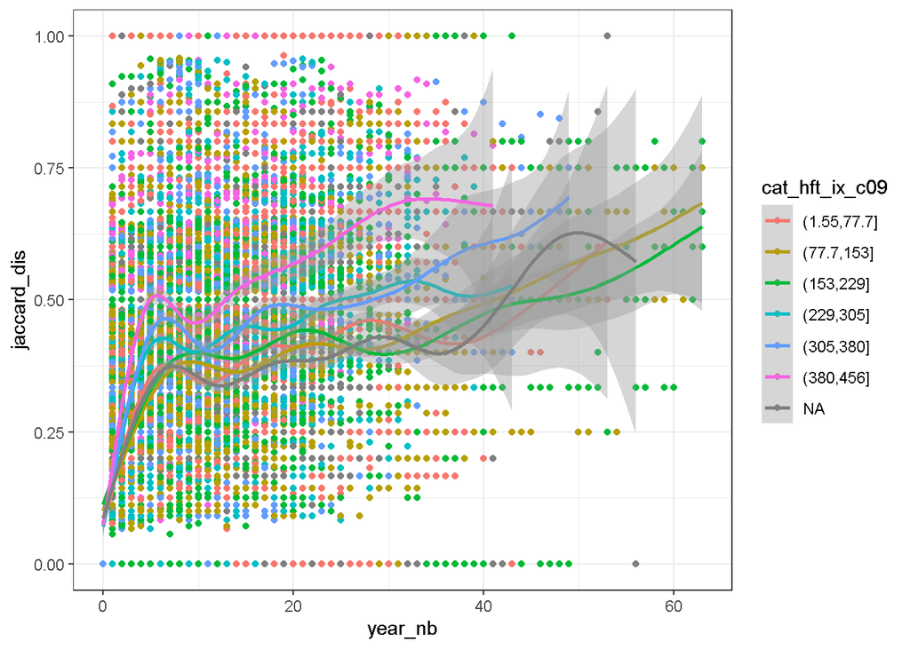

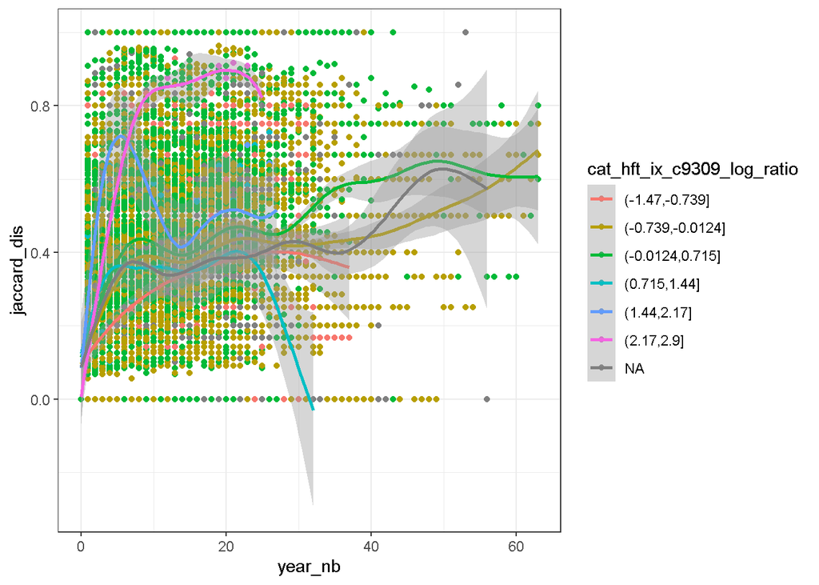

```r
p_jaccard_y_c9309_log_ratio <- map(
  c("cat_hft_ix_c93", "cat_hft_ix_c09", "cat_hft_ix_c9309_log_ratio"),
  ~hftc_biodiv %>%
    ggplot(aes(y = jaccard_dis, x = year_nb,
        color = !!sym(.x))) +
    geom_point() +
    geom_smooth()

)
p_jaccard_y_c9309_log_ratio
```

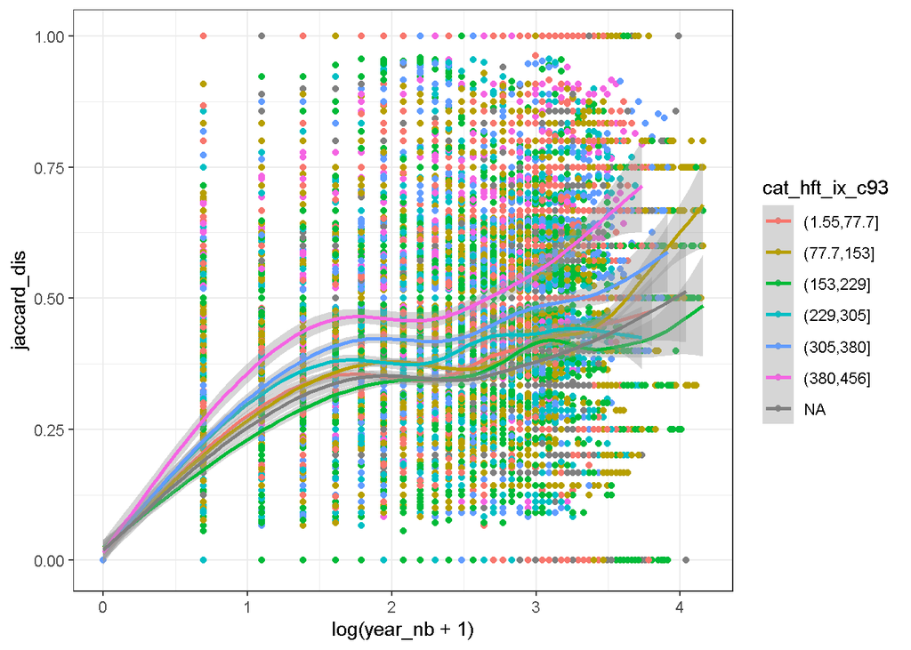

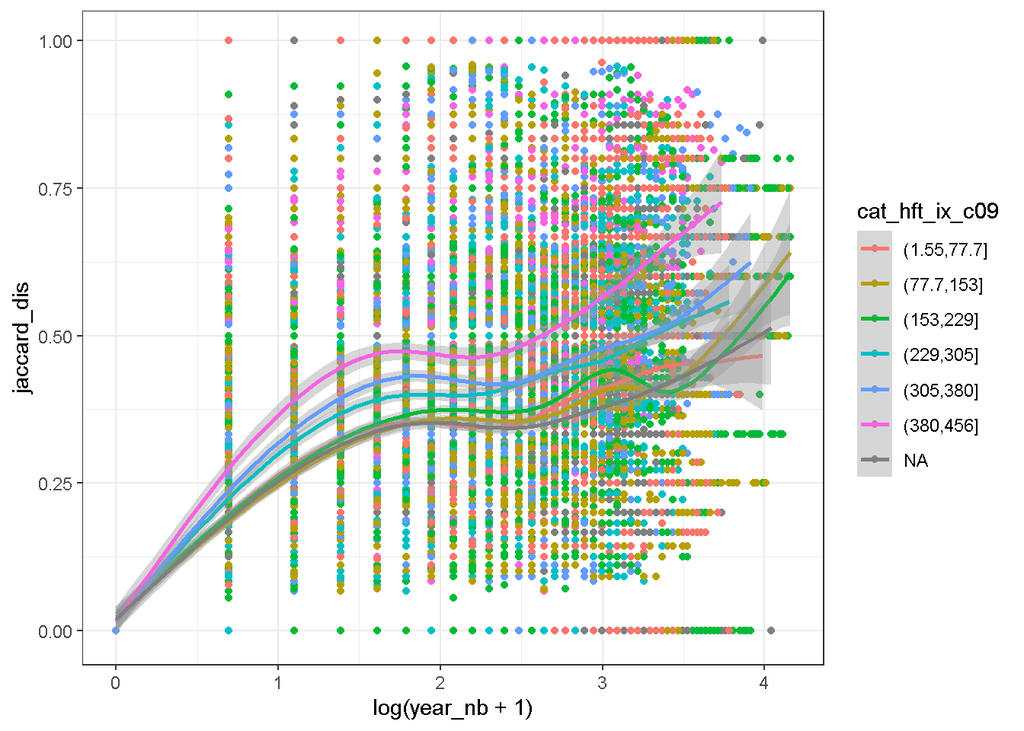

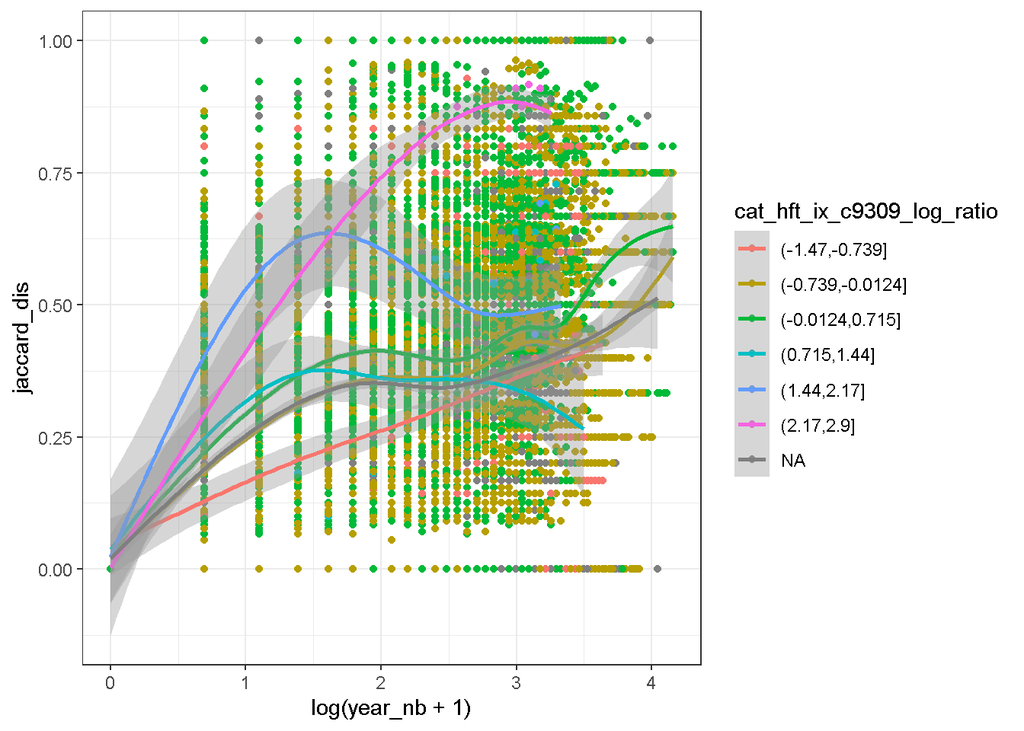

```r
p_jaccard_log_y_c9309_log_ratio <- map(
  c("cat_hft_ix_c93", "cat_hft_ix_c09", "cat_hft_ix_c9309_log_ratio"),
  ~hftc_biodiv %>%
    ggplot(aes(y = jaccard_dis, x = log(year_nb + 1),
        color = !!sym(.x))) +
    geom_point() +
    geom_smooth()

)
p_jaccard_log_y_c9309_log_ratio
```

- Correlation:

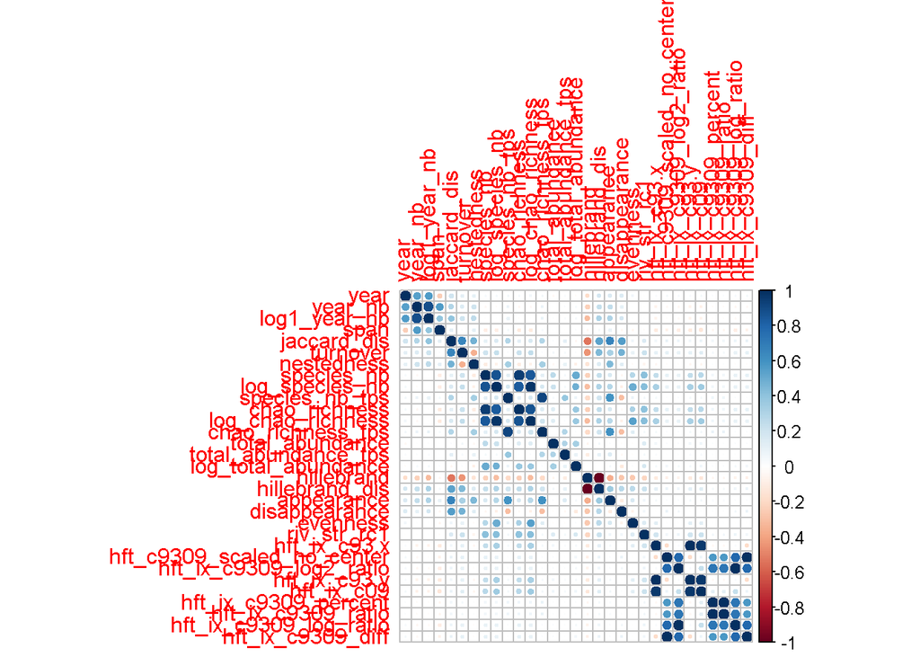

```r
cor_data <- modelling_data %>%
  left_join(hftc, by = "siteid") %>%
  select(
    !starts_with("cat") & !ends_with("scaled") & !starts_with("log_hft") & !starts_with("scaled")
    ) %>%
  select(-siteid, -main_bas, -unitabundance)

corrplot::corrplot(
  cor(as.matrix(na.omit(cor_data), method = c("spearman")))
  )
```

## 9.2 SpaMM model

```r
knitr::opts_chunk$set(eval = FALSE)
```

```r
tu <- ti %>%
  mutate(
    m = list(lm(appearance ~ ord_stra, data = data))
    ,
    coef = list(broom.mixed::tidy(m))
  ) %>%
  unnest(coef) %>%
  filter(term == "ord_stra") %>%
  ungroup()

stat_data <- slp_riv %>%
  mutate(
    appearance = scale(appearance),
    ord_stra = as.factor(ord_stra),
    main_bas = as.factor(main_bas),
    log_dist_up_km = log(dist_up_km)
  )

m0 <- spaMM::fitme(appearance ~ ord_stra, stat_data)
plot(m0)

m1 <- spaMM::fitme(appearance ~ ord_stra + (1 | main_bas),
  stat_data)

m2 <- spaMM::fitme(
  appearance ~ ord_stra + (1 + ord_stra | main_bas),
  stat_data
)

m2d <- spaMM::fitme(
  appearance ~ dist_up_km + (1 + dist_up_km | main_bas),
  stat_data
)
summary(m2d)

m2d <- spaMM::fitme(
  appearance ~ log_dist_up_km + (1 + log_dist_up_km | ecoregion/main_bas/siteid),
  stat_data
)
summary(m2d)
plot(m2d)


tm <- stat_data %>%
  na.omit() %>%
  mutate(
    pred_appearance = predict(m2d,
                              re.form = ~log_dist_up_km + (1 + log_dist_up_km | ecoregion))[,1]
  )
tm %>%
  ggplot(aes(x = log_dist_up_km, y = pred_appearance, color = ecoregion)) +
  geom_line()
```

```r
formula <- paste0(
  "jaccard",
  " ~ ",
  "year", "+", "year:ord_stra", " + ", "(1 + year:ord_stra| ecoregion/main_bas/siteid)"
)
spaMM::fitme(formula = formula, data = analysis_dataset)

formula <- paste0(
  "jaccard",
  " ~ ",
  "dis_up_km + tmp_dc_cyr + (1 + dist_up_km + tmp_dc_cyr | ecoregion/main_bas/siteid)"
)
```

```r
m3 <- spaMM::fitme(scale(appearance) ~ ord_stra + (1 | main_bas) +
  Matern(1 | longitude + latitude),
  na.omit(slp_riv), control.HLfit = list(algebra = "decorr"))
```

- Disappearance:

```r
tu <- ti %>%
  mutate(
    m = list(lm(disappearance ~ log(dist_up_km), data = data)),
    coef = list(broom::tidy(m))
  ) %>%
  unnest(coef) %>%
  filter(term == "log(dist_up_km)") %>%
  ungroup()

tu %>%
  ggplot(aes(x = estimate)) +
  geom_histogram()

summary(lm(disappearance ~ log(dist_up_km), slp_riv))
```

```r
cor_slp_env <-
  slp_riv[, !colnames(slp_riv) %in% c("siteid", "ecoregion", "main_bas")] %>%
  na.omit() %>%
  cor(., method = "spearman")
```

```r
corrplot::corrplot(
  cor_slp_env
)
```

```r
rigal_trends_df %>%
  ggplot(aes(x = jaccard , y = hillebrand)) +
  geom_point() +
#  geom_smooth(method = "gam") +
  labs(x = "Jaccard trends (similarity, binary)", y = "Hillebrand trends
    (similarity, relative abundance)")
```

```r
library(INLA)
a3 <- inla(scale(appearance) ~ ord_stra + f(main_bas, model = "iid"),
  family = "gaussian",
  control.predictor = list(link = 1, compute = TRUE),
  control.compute = list(cpo = TRUE, dic = TRUE, config = TRUE),
  data = slp_riv)
```

## 9.3 PCA on temporal trends

```r
slope_df <- rigal_slp_df
```

```r
res.pca <- dudi.pca(select(slope_df, -siteid),
  scannf = FALSE,   # Hide scree plot
  nf = 5            # Number of components kept in the results
)
```

```r
fviz_eig(res.pca)
```

```r
p_pca <- map(list(c(1,2), c(2, 3), c(1, 3)),
  ~fviz_pca_var(res.pca,
    axes = .x,
    col.var = "contrib", # Color by contributions to the PC
    gradient.cols = c("#00AFBB", "#E7B800", "#FC4E07"),
    repel = TRUE     # Avoid text overlapping
    ) +
  theme(legend.position = "none") + labs(title = "")
)

plot_grid(plotlist = p_pca, ncol = 1)
```

## 9.4 Reproducibility

**Reproducibility receipt**

```r
## datetime
Sys.time()

## repository
if(requireNamespace('git2r', quietly = TRUE)) {
  git2r::repository()
} else {
  c(
    system2("git", args = c("log", "--name-status", "-1"), stdout = TRUE),
    system2("git", args = c("remote", "-v"), stdout = TRUE)
  )
}

## session info
sessionInfo()
```